# STAT4620 Project

Catherine Ling.273

2025-12-02

```r
library(tidyverse)
library(GGally)
library(corrplot)
library(glmnet)

ames <- read_csv("train.csv", show_col_types = FALSE)

glimpse(ames)
```

```
## Rows: 1,460
## Columns: 81
## $ Id            <dbl> 1, 2, 3, 4, 5, 6, 7, 8, 9, 10, 11, 12, 13, 14, 15, 16, 1…
## $ MSSubClass    <dbl> 60, 20, 60, 70, 60, 50, 20, 60, 50, 190, 20, 60, 20, 20,…
## $ MSZoning      <chr> "RL", "RL", "RL", "RL", "RL", "RL", "RL", "RL", "RM", "R…
## $ LotFrontage   <dbl> 65, 80, 68, 60, 84, 85, 75, NA, 51, 50, 70, 85, NA, 91, …
## $ LotArea       <dbl> 8450, 9600, 11250, 9550, 14260, 14115, 10084, 10382, 612…
## $ Street        <chr> "Pave", "Pave", "Pave", "Pave", "Pave", "Pave", "Pave", …
## $ Alley         <chr> NA, NA, NA, NA, NA, NA, NA, NA, NA, NA, NA, NA, NA, NA, …
## $ LotShape      <chr> "Reg", "Reg", "IR1", "IR1", "IR1", "IR1", "Reg", "IR1", …
## $ LandContour   <chr> "Lvl", "Lvl", "Lvl", "Lvl", "Lvl", "Lvl", "Lvl", "Lvl", …
## $ Utilities     <chr> "AllPub", "AllPub", "AllPub", "AllPub", "AllPub", "AllPu…
## $ LotConfig     <chr> "Inside", "FR2", "Inside", "Corner", "FR2", "Inside", "I…
## $ LandSlope     <chr> "Gtl", "Gtl", "Gtl", "Gtl", "Gtl", "Gtl", "Gtl", "Gtl", …
## $ Neighborhood  <chr> "CollgCr", "Veenker", "CollgCr", "Crawfor", "NoRidge", "…
```

[output cut: 68 more lines]

# Part I: Exploratory Data Analysis

## Dataset Introduction

The Ames Housing dataset contains residential home sales in Ames, Iowa from 2006–2010 and includes 79 predictors describing lot characteristics, house quality, building type, square footage, basement and garage features, and neighborhood information. The response variable for modeling is SalePrice, the sale price of each home in USD.

The dataset contains a mixture of numeric, ordinal, and nominal variables. Its initial state:

```r
# summary statistics
summary(ames)
```

```
##        Id           MSSubClass      MSZoning          LotFrontage
##  Min.   :   1.0   Min.   : 20.0   Length:1460        Min.   : 21.00
##  1st Qu.: 365.8   1st Qu.: 20.0   Class :character   1st Qu.: 59.00
##  Median : 730.5   Median : 50.0   Mode  :character   Median : 69.00
##  Mean   : 730.5   Mean   : 56.9                      Mean   : 70.05
##  3rd Qu.:1095.2   3rd Qu.: 70.0                      3rd Qu.: 80.00
##  Max.   :1460.0   Max.   :190.0                      Max.   :313.00
##                                                      NA's   :259
##     LotArea          Street             Alley             LotShape
##  Min.   :  1300   Length:1460        Length:1460        Length:1460
##  1st Qu.:  7554   Class :character   Class :character   Class :character
##  Median :  9478   Mode  :character   Mode  :character   Mode  :character
##  Mean   : 10517
##  3rd Qu.: 11602
##  Max.   :215245
##
##  LandContour         Utilities          LotConfig          LandSlope
##  Length:1460        Length:1460        Length:1460        Length:1460
##  Class :character   Class :character   Class :character   Class :character
##  Mode  :character   Mode  :character   Mode  :character   Mode  :character
##
##
##
##
##  Neighborhood        Condition1         Condition2          BldgType
##  Length:1460        Length:1460        Length:1460        Length:1460
##  Class :character   Class :character   Class :character   Class :character
##  Mode  :character   Mode  :character   Mode  :character   Mode  :character
##
##
##
##
##   HouseStyle         OverallQual      OverallCond      YearBuilt
##  Length:1460        Min.   : 1.000   Min.   :1.000   Min.   :1872
##  Class :character   1st Qu.: 5.000   1st Qu.:5.000   1st Qu.:1954
##  Mode  :character   Median : 6.000   Median :5.000   Median :1973
##                     Mean   : 6.099   Mean   :5.575   Mean   :1971
##                     3rd Qu.: 7.000   3rd Qu.:6.000   3rd Qu.:2000
##                     Max.   :10.000   Max.   :9.000   Max.   :2010
##
```

[output cut: 113 more lines]

```
##  Min.   : 1.000   Min.   :2006   Length:1460        Length:1460
##  1st Qu.: 5.000   1st Qu.:2007   Class :character   Class :character
##  Median : 6.000   Median :2008   Mode  :character   Mode  :character
##  Mean   : 6.322   Mean   :2008
##  3rd Qu.: 8.000   3rd Qu.:2009
##  Max.   :12.000   Max.   :2010
##
##    SalePrice
##  Min.   : 34900
##  1st Qu.:129975
##  Median :163000
##  Mean   :180921
##  3rd Qu.:214000
##  Max.   :755000
##
```

```r
# split by variable type
numeric_vars <- ames %>% select(where(is.numeric))
categorical_vars <- ames %>% select(where(~ !is.numeric(.)))
```

## Missing Data

several variables contain missing values, but many of these are structural (“feature not present”) rather than incomplete. For example, if a house has no basement, basement quality fields are NA.

```r
missing_summary <- ames %>%
  summarise(across(everything(), ~ sum(is.na(.)))) %>%
  pivot_longer(everything(), names_to = "variable", values_to = "missing") %>%
  arrange(desc(missing))

missing_summary
```

```
## # A tibble: 81 × 2
##    variable     missing
##    <chr>          <int>
##  1 PoolQC          1453
##  2 MiscFeature     1406
##  3 Alley           1369
##  4 Fence           1179
##  5 FireplaceQu      690
##  6 LotFrontage      259
##  7 GarageType        81
##  8 GarageYrBlt       81
##  9 GarageFinish      81
## 10 GarageQual        81
## # ℹ 71 more rows
```

Findings:

- Variables with very high missingness include PoolQC, MiscFeature, Alley, and Fence, which is expected because most homes do not have pools, miscellaneous features, alleys, and fences
- Basement and garage quality variables also include NAs for homes without basements or garages
- LotFrontage has ~18% missingness, representing true unobserved data rather than a structural “None”

```r
# convert known structural NAs to "None"
ames <- ames %>%
  mutate(
    Alley        = replace_na(Alley, "None"),
    PoolQC       = replace_na(PoolQC, "None"),
    Fence        = replace_na(Fence, "None"),
    MiscFeature  = replace_na(MiscFeature, "None"),
    FireplaceQu  = replace_na(FireplaceQu, "None"),
    GarageType   = replace_na(GarageType, "None"),
    GarageFinish = replace_na(GarageFinish, "None"),
    GarageQual   = replace_na(GarageQual, "None"),
    GarageCond   = replace_na(GarageCond, "None"),
    BsmtQual     = replace_na(BsmtQual, "None"),
    BsmtCond     = replace_na(BsmtCond, "None"),
    BsmtExposure = replace_na(BsmtExposure, "None"),
    BsmtFinType1 = replace_na(BsmtFinType1, "None"),
    BsmtFinType2 = replace_na(BsmtFinType2, "None")
  )
```

## Distribution of Variables

**SalePrice**

One notable issue is that SalePrice is heavily right-skewed, which violates the normality assumption of linear regression.

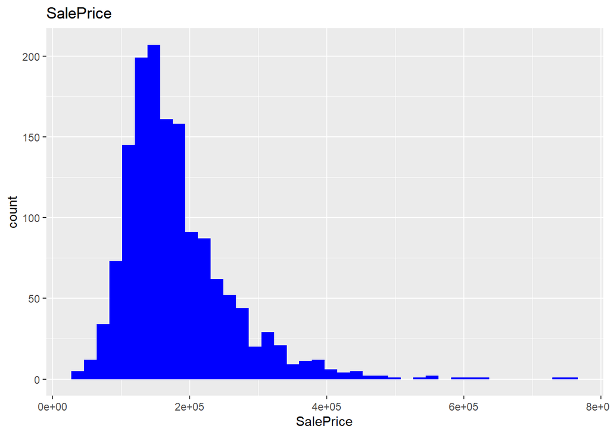

```r
# histograms
ggplot(ames, aes(x = SalePrice)) +
  geom_histogram(bins = 40, fill = "blue") +
  labs(title = "SalePrice")
```

A log-transformation produces a much more symmetric distribution:

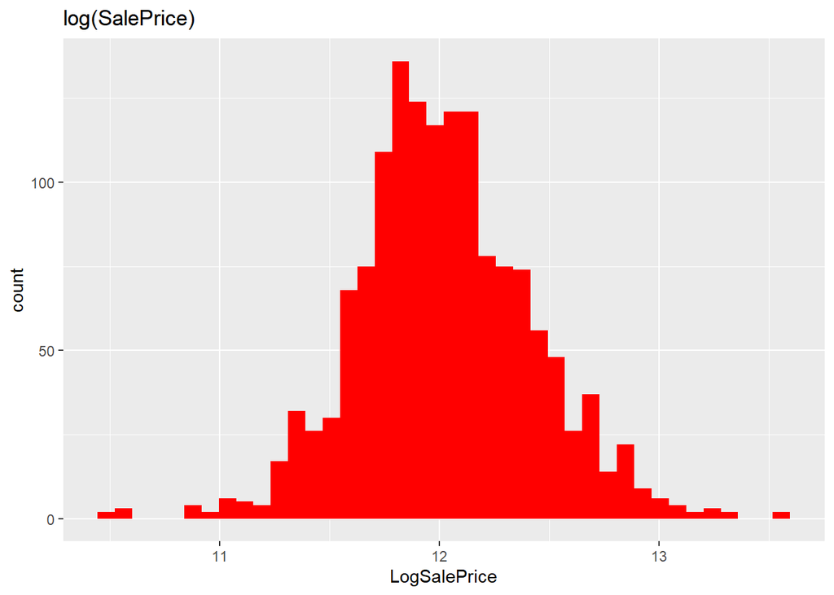

```r
# log transformation to normalize
ames <- ames %>% mutate(LogSalePrice = log(SalePrice))

ggplot(ames, aes(x = LogSalePrice)) +
  geom_histogram(bins = 40, fill = "red") +
  labs(title = "log(SalePrice)")
```

Skewness suggests that data transformations (e.g., log) or models that don’t require linearity would be best suited for this dataset.

**Numeric Variables**

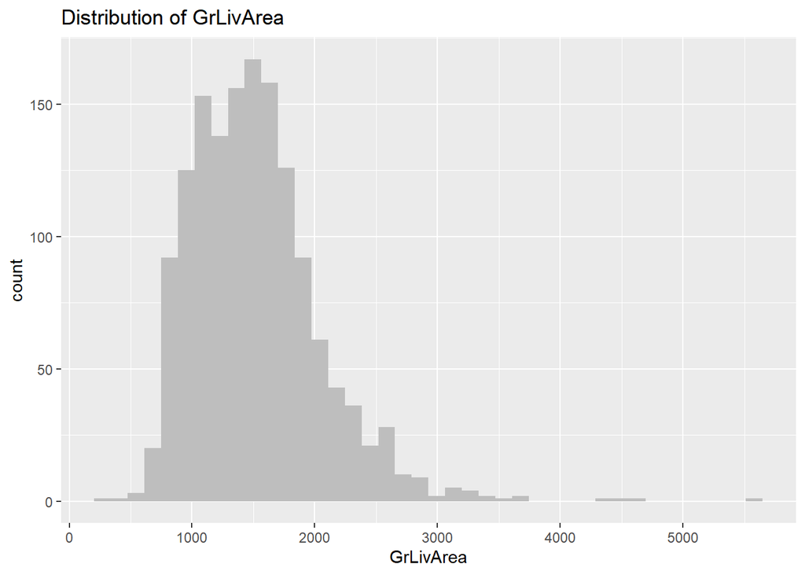

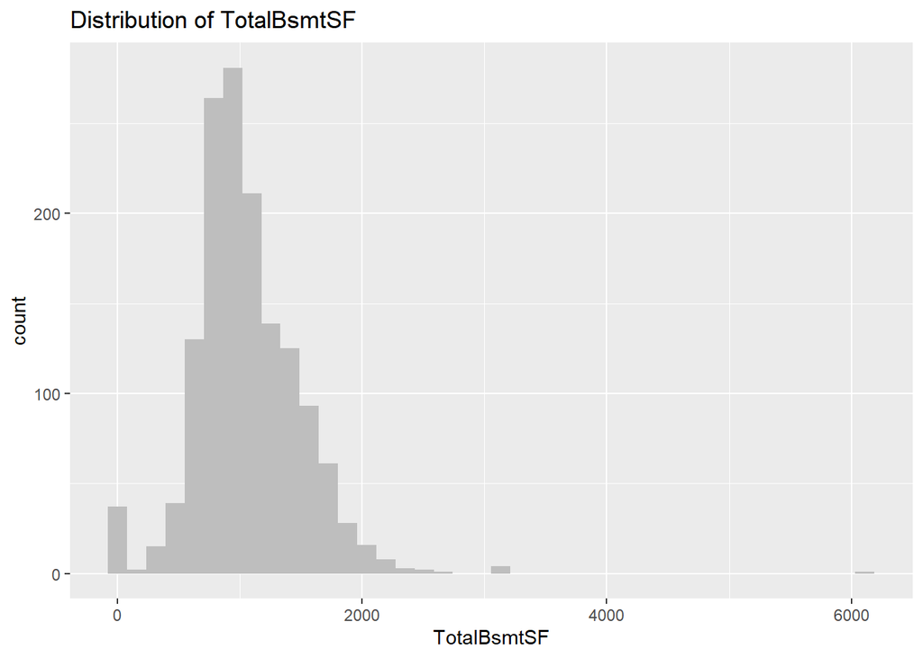

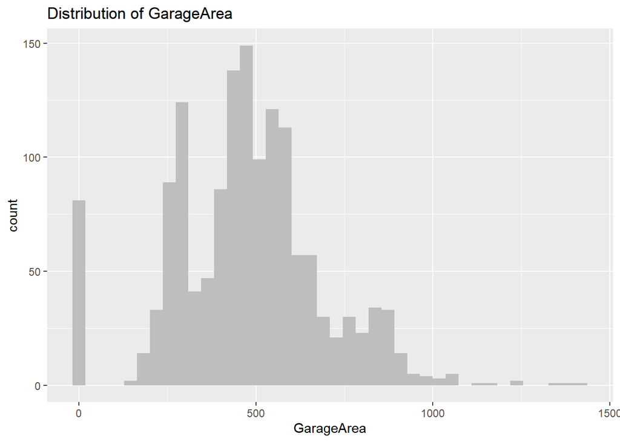

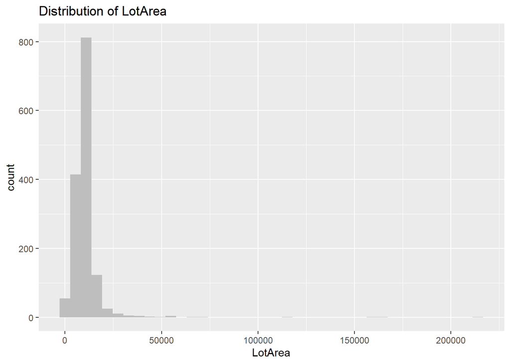

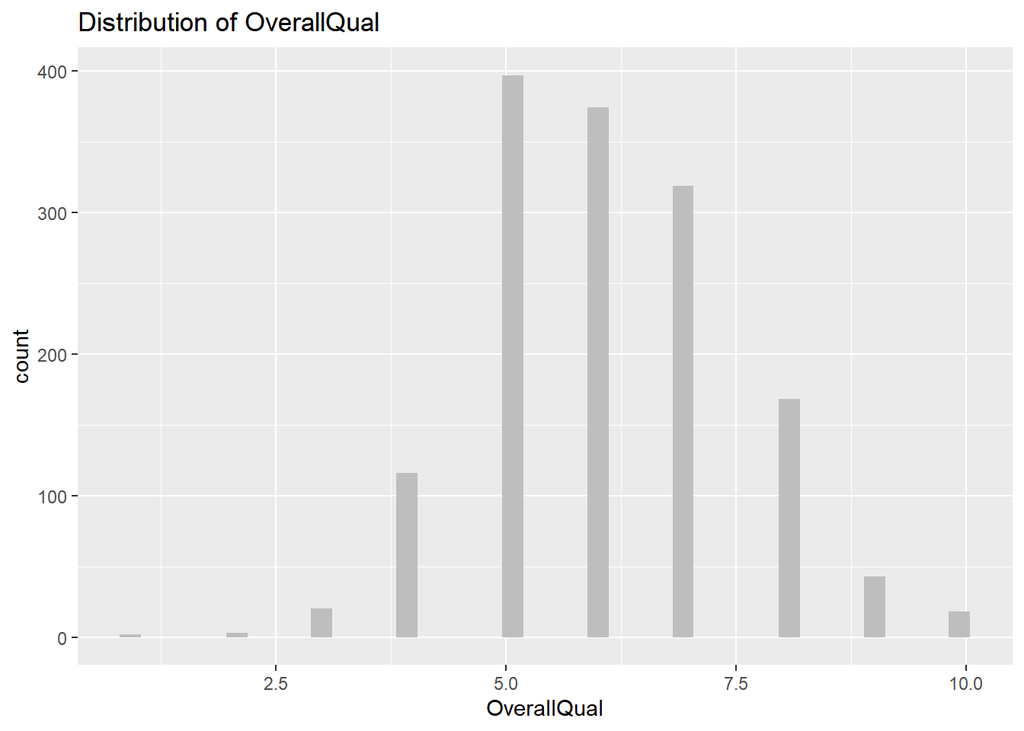

```r
key_numeric <- c("GrLivArea", "TotalBsmtSF", "GarageArea", "LotArea",
                 "X1stFlrSF", "X2ndFlrSF", "OverallQual")

key_numeric <- intersect(key_numeric, names(ames))

for (var in key_numeric) {
  print(
    ggplot(ames, aes_string(x = var)) +
      geom_histogram(bins = 40, fill = "gray") +
      labs(title = paste("Distribution of", var))
  )
}
```

## Relationships with SalePrice

**Size/area variables**

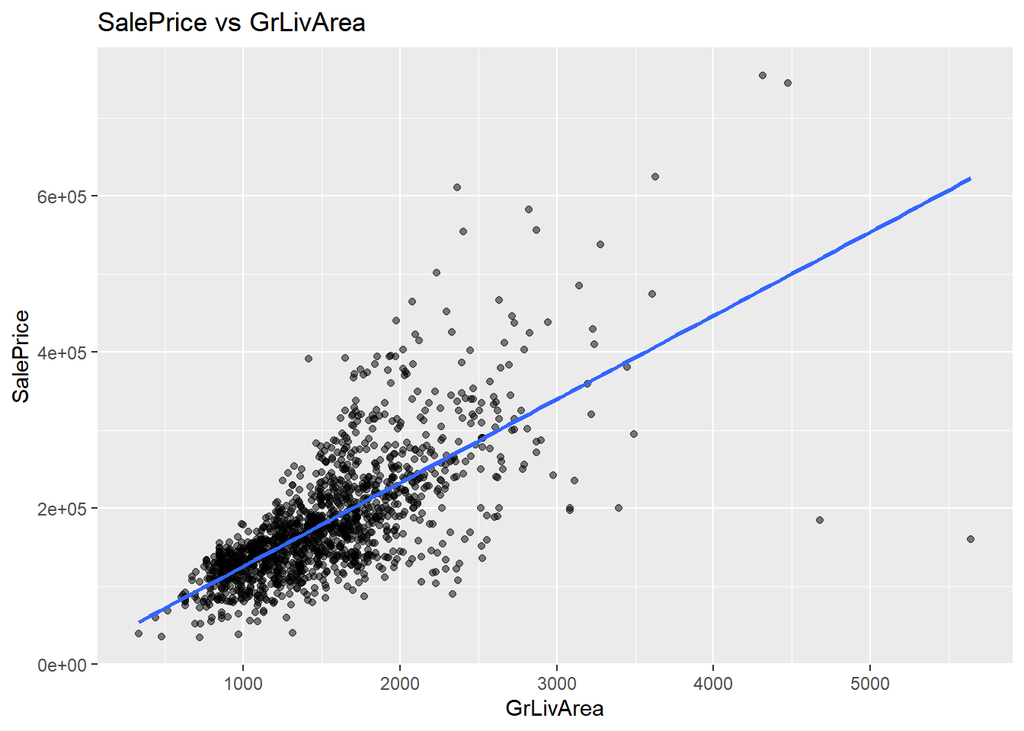

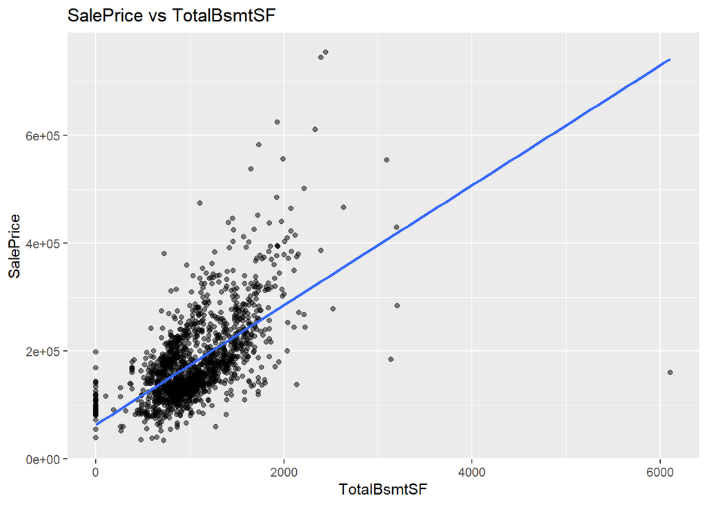

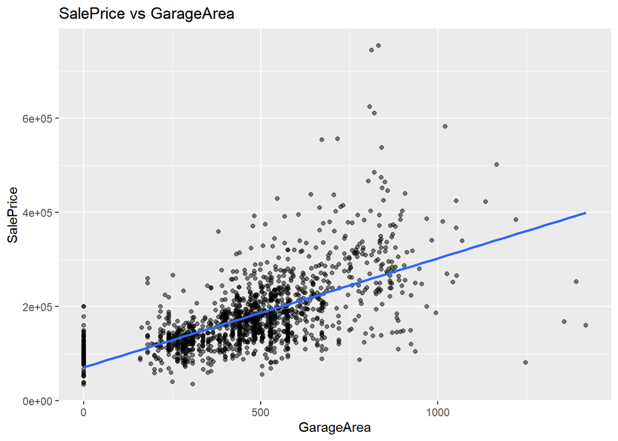

```r
# scatterplots for numeric predictors
size_vars <- intersect(c("GrLivArea", "TotalBsmtSF", "GarageArea", "X1stFlrSF"), names(ames))

for (var in size_vars) {
  print(
    ggplot(ames, aes_string(x = var, y = "SalePrice")) +
      geom_point(alpha = 0.5) +
      geom_smooth(method = "lm", se = FALSE) +
      labs(title = paste("SalePrice vs", var))
  )
}
```

- GrLivArea and TotalBsmtSF show strong positive linear trends.
- Outliers exist for very large homes (>4000 sq ft).

**Quality**

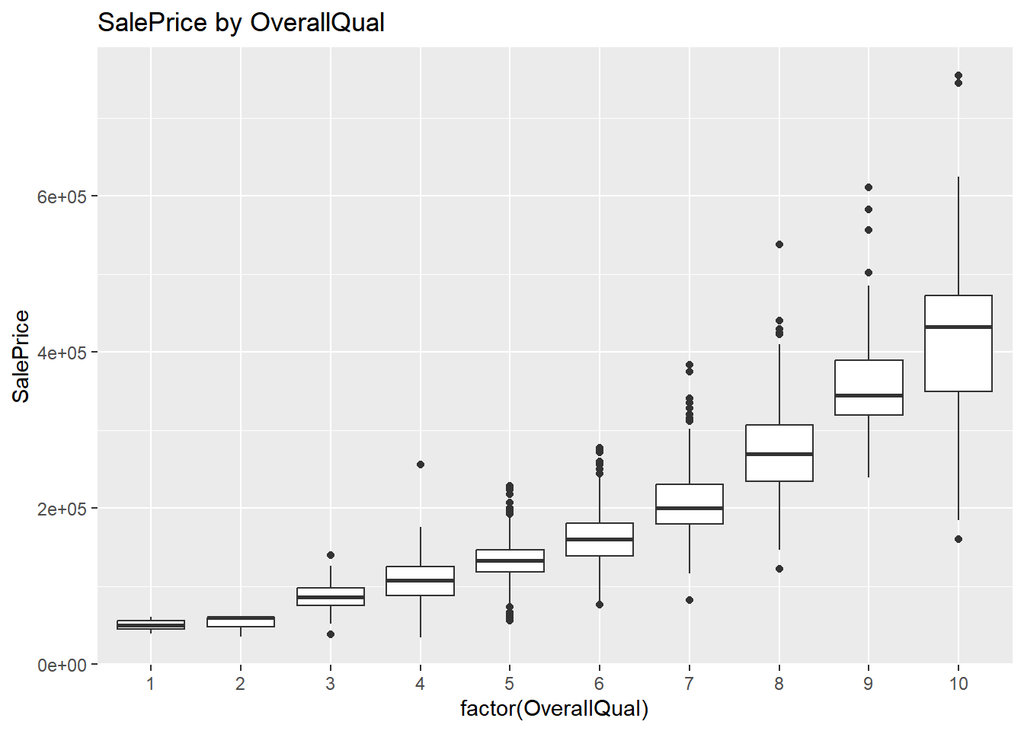

```r
# overallQual boxplot
if ("OverallQual" %in% names(ames)) {
  ggplot(ames, aes(x = factor(OverallQual), y = SalePrice)) +
    geom_boxplot() +
    labs(title = "SalePrice by OverallQual")
}
```

Higher OverallQual correlates strongly with higher prices, showing a step-like increase.

**Neighborhood**

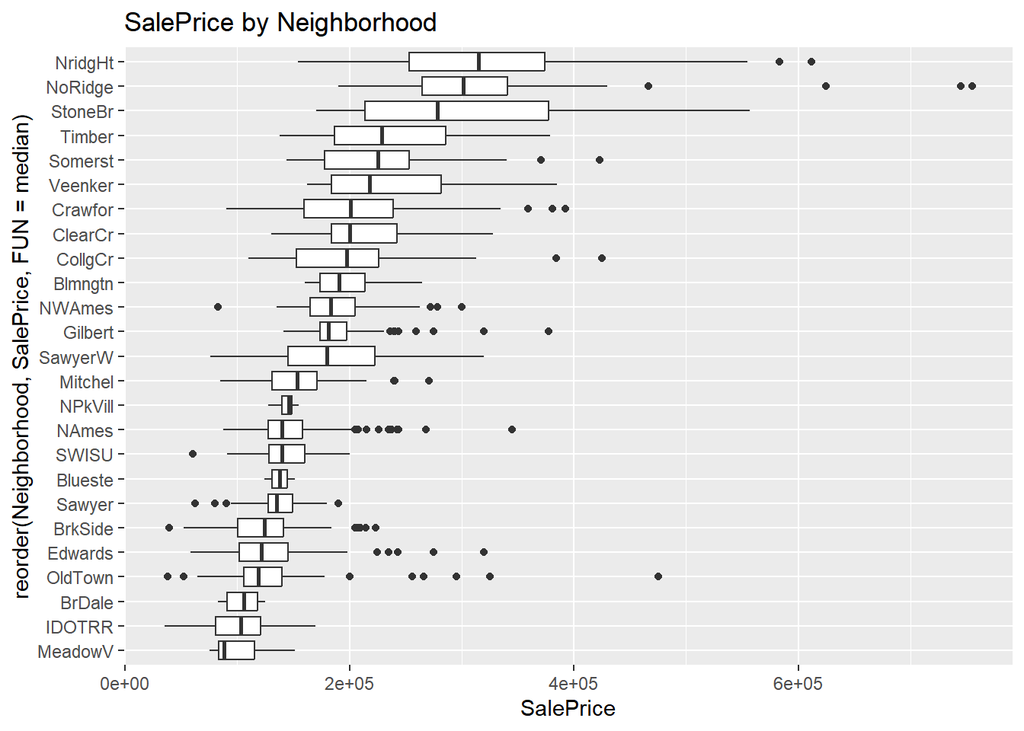

```r
# neighborhood boxplot
if ("Neighborhood" %in% names(ames)) {
  ggplot(ames, aes(x = reorder(Neighborhood, SalePrice, FUN = median),
                   y = SalePrice)) +
    geom_boxplot() +
    coord_flip() +
    labs(title = "SalePrice by Neighborhood")
}
```

Neighborhoods differ substantially in median home value, implying they are relatively important predictors.

## Correlation & Collinearity

```r
cor_matrix <- numeric_vars %>% cor(use = "pairwise.complete.obs")

# correlation with SalePrice
cor_with_price <- sort(cor_matrix[,"SalePrice"], decreasing = TRUE)
cor_with_price
```

```
##     SalePrice   OverallQual     GrLivArea    GarageCars    GarageArea
##    1.00000000    0.79098160    0.70862448    0.64040920    0.62343144
##   TotalBsmtSF      1stFlrSF      FullBath  TotRmsAbvGrd     YearBuilt
##    0.61358055    0.60585218    0.56066376    0.53372316    0.52289733
##  YearRemodAdd   GarageYrBlt    MasVnrArea    Fireplaces    BsmtFinSF1
##    0.50710097    0.48636168    0.47749305    0.46692884    0.38641981
##   LotFrontage    WoodDeckSF      2ndFlrSF   OpenPorchSF      HalfBath
##    0.35179910    0.32441344    0.31933380    0.31585623    0.28410768
##       LotArea  BsmtFullBath     BsmtUnfSF  BedroomAbvGr   ScreenPorch
##    0.26384335    0.22712223    0.21447911    0.16821315    0.11144657
##      PoolArea        MoSold     3SsnPorch    BsmtFinSF2  BsmtHalfBath
##    0.09240355    0.04643225    0.04458367   -0.01137812   -0.01684415
##       MiscVal            Id  LowQualFinSF        YrSold   OverallCond
##   -0.02118958   -0.02191672   -0.02560613   -0.02892259   -0.07785589
##    MSSubClass EnclosedPorch  KitchenAbvGr
##   -0.08428414   -0.12857796   -0.13590737
```

```r
# top correlated predictors
top_corr <- names(head(cor_with_price, 10))
```

Strongest correlations: - OverallQual (0.79) - GrLivArea (0.71) - GarageCars, GarageArea, TotalBsmtSF, 1stFlrSF (~0.60 - 0.64)

multicollinearity among top predictors:

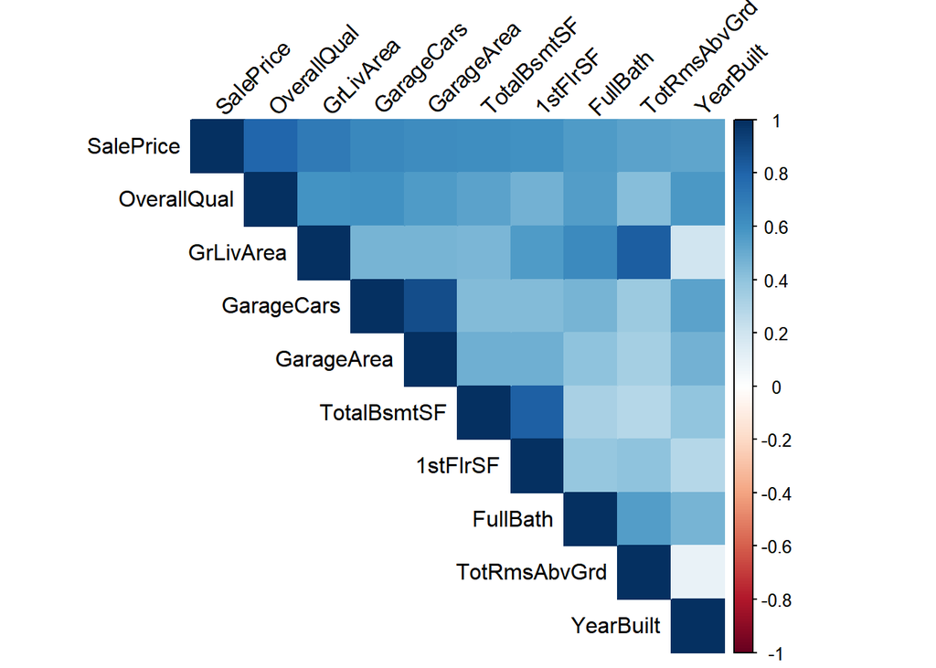

```r
cor_top <- numeric_vars %>%
  select(all_of(top_corr)) %>%
  cor(use = "pairwise.complete.obs")

# heatmap
corrplot(cor_top, method = "color", type = "upper",
         tl.col = "black", tl.srt = 45)
```

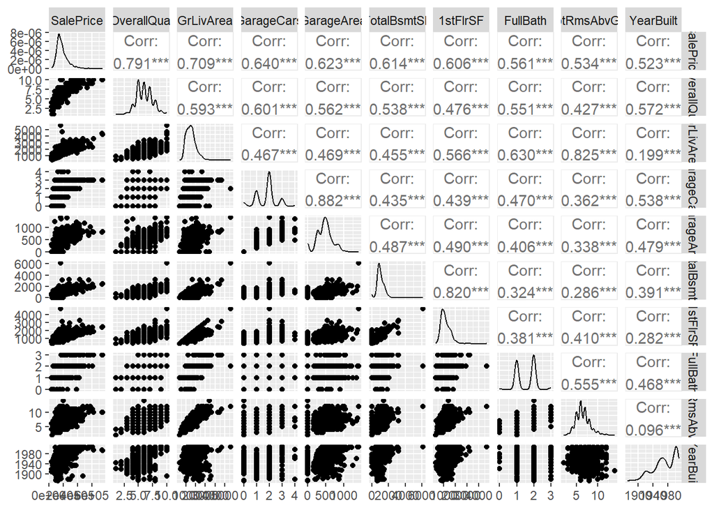

```r
# pairs plot
GGally::ggpairs(ames, columns = top_corr)
```

- GarageCars and GarageArea are highly collinear
- 1stFlrSF and TotalBsmtSF are strongly correlated
- Quality ratings like OverallQual correlate with other quality-related scores

Collinearity suggests models with regularization (Ridge/LASSO) or selective variable inclusion would work best.

## Other Problems

**Zero-inflation**

Several variables contain mostly zeros:

```
## PoolArea - proportion zeros: 0.995
```

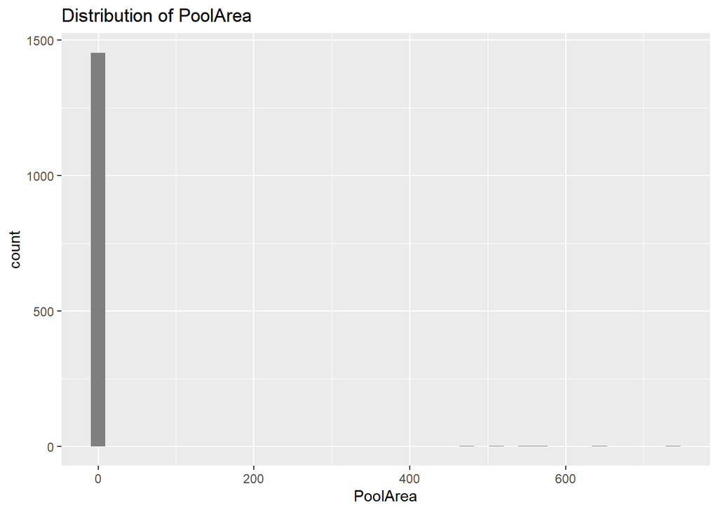

```
## MiscVal - proportion zeros: 0.964
```

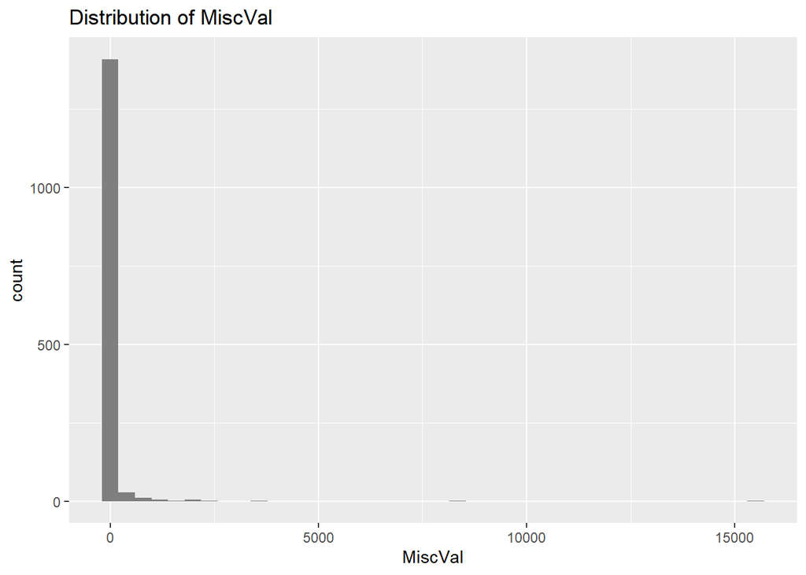

```
## ScreenPorch - proportion zeros: 0.921
```

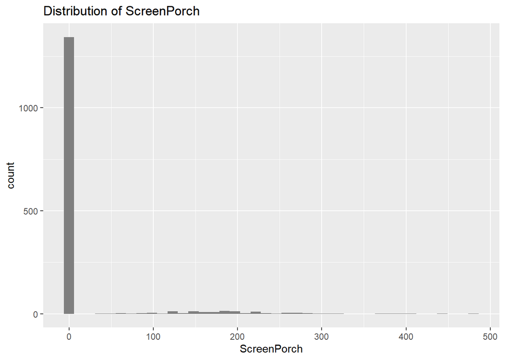

```
## EnclosedPorch - proportion zeros: 0.858
```

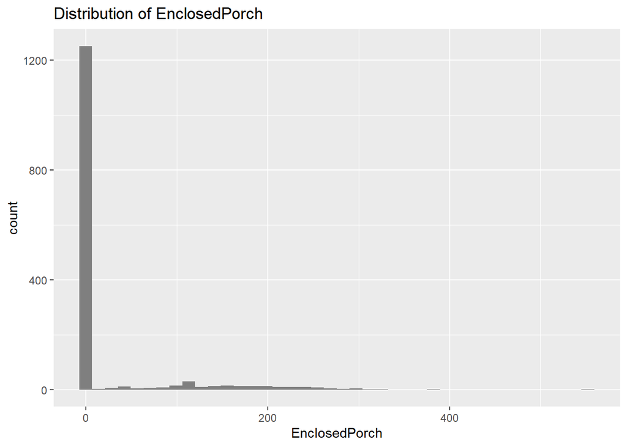

```
## LowQualFinSF - proportion zeros: 0.982
```

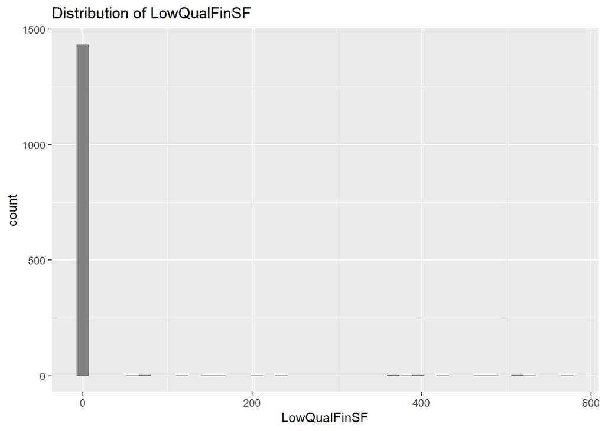

```r
zero_vars <- intersect(c("PoolArea", "MiscVal", "ScreenPorch",
                         "EnclosedPorch", "LowQualFinSF"), names(ames))

for (var in zero_vars) {
  zero_prop <- mean(ames[[var]] == 0)
  cat(var, "- proportion zeros:", round(zero_prop, 3), "\n")

  print(
    ggplot(ames, aes_string(x = var)) +
      geom_histogram(bins = 40, fill = "gray50") +
      labs(title = paste("Distribution of", var))
  )
}
```

**Outliers**

```r
if ("GrLivArea" %in% names(ames)) {
  ggplot(ames, aes(x = GrLivArea, y = SalePrice)) +
    geom_point(alpha = 0.5) +
    geom_smooth(method = "lm", se = FALSE) +
    labs(title = "Outlier Check: GrLivArea vs SalePrice")

  # view suspected outliers
  ames %>% filter(GrLivArea > 4000) %>%
    select(GrLivArea, SalePrice, OverallQual, Neighborhood)
}
```

```
## # A tibble: 4 × 4
##   GrLivArea SalePrice OverallQual Neighborhood
##       <dbl>     <dbl>       <dbl> <chr>
## 1      4676    184750          10 Edwards
## 2      4316    755000          10 NoRidge
## 3      4476    745000          10 NoRidge
## 4      5642    160000          10 Edwards
```

Houses with very large living area (>4000 sq ft) appear to be outliers and may disproportionately influence linear regression

# Part II: Model Analysis - LASSO Regression

## Motivation for Using LASSO

The EDA revealed:

- Many predictors are highly correlated (e.g., GarageCars with GarageArea, 1stFlrSF with TotalBsmtSF).
- The dataset contains many potential predictors (~79).
- Some predictors may be irrelevant or redundant.
- Linear relationships appear strong, especially after transforming SalePrice.

Because of this, ordinary least squares (OLS) would be unstable and prone to overfitting due to multicollinearity and high dimensionality.

LASSO regression (Least Absolute Shrinkage and Selection Operator) performs:

- Regularization -> improves generalization
- Variable selection -> shrinks coefficients of unimportant variables to zero
- Handles multicollinearity better than OLS

Thus, LASSO is an appropriate modeling strategy for this dataset.

**The LASSO Model**

Given predictors $X_1, X_2, ..., X_p$ and response $y$, LASSO solves:

$$\hat{\beta} = \arg\min_\beta \left(
\sum^n_{i=1}(y_i-\beta_0-\sum^p_{j=1} X_{ij} \beta_j)^2 + \lambda
\sum^p_{j=1} |\beta_j| \right)$$

where $\lambda \ge 0$ controls shrinkage.

## Data Preparation

Training data log-transform:

```r
ames <- read_csv("train.csv") %>%
  mutate(
    log_price = log(SalePrice)
  )
```

Handling missing values:

- for character predictors: replace NA with “None”, then convert to factor
- for numeric predictors (other than Id, SalePrice, log_price): median impute

```r
ames_clean <- ames %>%
  # character -> "None" where NA
  mutate(across(where(is.character), ~ replace_na(., "None"))) %>%
  # now convert all characters to factors
  mutate(across(where(is.character), factor))

# numeric predictors (exclude Id, SalePrice, log_price)
num_pred <- names(ames_clean)[sapply(ames_clean, is.numeric) &
                                !(names(ames_clean) %in% c("Id", "SalePrice", "log_price"))]

ames_clean <- ames_clean %>%
  mutate(
    across(all_of(num_pred),
           ~ replace_na(., median(., na.rm = TRUE)))
  )

# drop factor columns with only ONE level
fac_cols  <- sapply(ames_clean, is.factor)
one_level <- names(ames_clean)[fac_cols][sapply(ames_clean[fac_cols], nlevels) < 2]

ames_mod <- ames_clean %>%
  select(-all_of(one_level),
         -Id)   # Id is just a label, not a predictor
```

Building design matrix:

```r
X <- model.matrix(
  log_price ~ . - SalePrice,  # all predictors except SalePrice (we use log_price)
  data = ames_mod
)[, -1]                        # drop intercept column; glmnet adds its own

y <- ames_mod$log_price
```

## Fitting the Model

```r
set.seed(123)

cv_lasso <- cv.glmnet(
  X, y,
  alpha  = 1,      # LASSO
  nfolds = 10
)

lambda_min <- cv_lasso$lambda.min
lambda_1se <- cv_lasso$lambda.1se

lambda_min
```

```
## [1] 0.006556409
```

```r
lambda_1se
```

```
## [1] 0.02904897
```

Visualizing the CV curve:

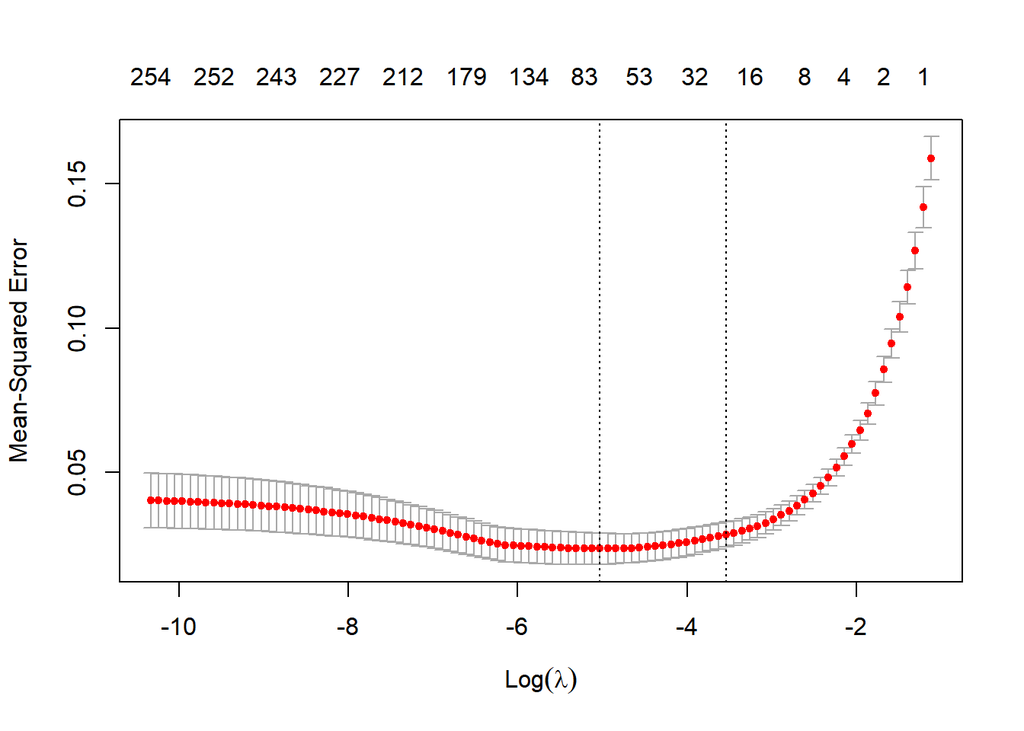

```r
plot(cv_lasso)
```

Fitting the final model:

```r
lasso_model <- glmnet(X, y, alpha = 1, lambda = lambda_min)
```

Results:

```r
coef_summary <- coef(lasso_model) %>%
  as.matrix() %>%
  as.data.frame() %>%
  rownames_to_column("Variable") %>%
  rename(Coefficient = s0) %>%
  filter(Coefficient != 0) %>%
  arrange(desc(abs(Coefficient)))

coef_summary
```

```
##               Variable   Coefficient
## 1          (Intercept)  6.054739e+00
## 2       Condition2PosN -4.909737e-01
## 3             PoolQCGd -3.258874e-01
## 4       FunctionalMaj2 -1.212564e-01
## 5        FunctionalSev -1.086970e-01
## 6  NeighborhoodCrawfor  9.478796e-02
## 7  NeighborhoodNridgHt  9.053334e-02
## 8  NeighborhoodStoneBr  7.929678e-02
## 9   Exterior1stBrkComm -7.887122e-02
## 10         OverallQual  7.300899e-02
## 11         HeatingGrav -7.136330e-02
## 12         CentralAirY  6.213852e-02
## 13         SaleTypeNew  5.946822e-02
## 14          GarageCars  5.563183e-02
```

[output cut: 61 more lines]

## Testing

```r
# read test data
test <- read_csv("test_new.csv")

# handle missing values and character variables the same way as training
test_clean <- test %>%
  # replace na in character columns with "none"
  mutate(across(where(is.character), ~ replace_na(., "None"))) %>%
  # convert characters to factors
  mutate(across(where(is.character), factor))
```

```r
# compute training medians for numeric predictors
train_medians <- sapply(ames_clean[num_pred], median, na.rm = TRUE)

# apply median imputation to numeric predictors in test using training medians
for (v in num_pred) {
  if (v %in% names(test_clean)) {
    test_clean[[v]] <- replace_na(test_clean[[v]], train_medians[[v]])
  }
}

# drop the same single-level factor columns and id as in training
test_mod <- test_clean %>%
  select(-all_of(one_level),
         -Id)
```

```r
# build model matrix for test data (no response in formula)
X_test <- model.matrix(
  ~ . - SalePrice,   # same predictor structure as training
  data = test_mod
)[, -1]              # drop intercept column

# align test design matrix columns with training design matrix
train_cols <- colnames(X)
test_cols  <- colnames(X_test)

# add any columns that are in training but missing in test (fill with zeros)
missing_cols <- setdiff(train_cols, test_cols)
if (length(missing_cols) > 0) {
  X_test <- cbind(
    X_test,
    matrix(0, nrow(X_test), length(missing_cols),
           dimnames = list(NULL, missing_cols))
  )
}

# drop any extra columns that appear only in test
extra_cols <- setdiff(colnames(X_test), train_cols)
if (length(extra_cols) > 0) {
  X_test <- X_test[, setdiff(colnames(X_test), extra_cols)]
}

# reorder columns to match training matrix exactly
X_test <- X_test[, train_cols]
```

```r
# predict log-price on the test set
log_pred_test <- predict(lasso_model, newx = X_test, s = lambda_min)

# convert back from log scale to saleprice
saleprice_pred <- exp(log_pred_test)
```

```r
# extract true saleprice from test set
y_test <- test$SalePrice

# compute rmse (root mean squared error)
rmse <- sqrt(mean((y_test - saleprice_pred)^2))
rmse
```

```
## [1] 31109.51
```

```r
# compute mae
mae <- mean(abs(y_test - saleprice_pred))
mae
```

```
## [1] 15727.36
```

```r
# compute r-squared
sst <- sum((y_test - mean(y_test))^2)
sse <- sum((y_test - saleprice_pred)^2)
r_squared <- 1 - sse/sst
r_squared
```

```
## [1] 0.8503672
```

## Conclusion

The LASSO model was trained on the training dataset and evaluated using a separate test dataset. Model performance on the test set was assessed using RMSE, MAE, and $R^2$. The model achieved an RMSE of $31,110 and an MAE of $15,727, indicating that predictions are typically within about $16,000 of the true sale price, with some larger errors occurring. The test-set $R^2$ value of 0.85 shows that the model explains approximately 85% of the variability in housing prices on unseen data. Overall, these results indicate that the LASSO model generalizes well and provides strong predictive accuracy.